# analiza_covid

Michał Włodarczyk

11/18/2020

# Wykorzystane biblioteki

```r
library(readxl)
library(httr)
library(knitr)
library(plyr)
library(gridExtra)
library(tidyverse)
library(janitor)
library(scales)
library(kableExtra)
library(qwraps2)
```

# Wczytywanie danych

Surowe dane zostały pobrane z adresu url (http://www.cs.put.poznan.pl/dbrzezinski/teaching/zed/wuhan_blood_sample_data_Jan_Feb_2020.xlsx) bezpośrednio bez konieczności ręcznego pobierania zbioru danych w celu zapewnienia powtarzalności eksperymentów.

```r
GET(url, write_disk(data_file <- tempfile(fileext = ".xlsx")))
```

```r
raw_df <- read_excel(data_file)
```

# Przetwarzanie zbioru danych

## Czyszczenie zbioru danych

## Rozmiar danych

Zbiór danych składa się z 6120 rekordów medycznych opisywanych przez 81 atrybutów, z których pierwsze 7 odnosi się bezpośrednio do samego pacjenta (jego identyfikator, data przyjęcia do szpitala, wiek, …), a pozostałe 74 atrybuty zawierają informacje o wynikach przeprowadzonych badań.

## Pacjenci

Zbiór danych zawiera informacje o 375 pacjentach, u których stwierdzono obecność choroby COVID-19. Dane zostały zebrane na przestrzeni od 2020-01-10 do 2020-03-04.

### Atrybuty główne - informacje o pacjentach

- patient_id (PATIENT_ID) - unikalny identyfikator przypisany do każdego pacjenta
- test_date (RE_DATE) - pole, którego znaczenie w dokumentacji zbioru nie jest jednoznacznie opisane, ale na podstawie pozostałych atrybutów zbioru można wyprowadzić, że jest to data wykonania badania
- age - wiek pacjenta
- gender - płeć pacjenta, przyjmuje wartości 1 lub 2, gdzie 1 oznacza mężczyznę, a 2 kobietę. Przypisane wartości do płci nie było jawnie udokumentowane, natomiast poprawną identyfikację umożliwiały dopiero opublikowane statystyki zbioru.
- admission_date (Admission time) - data przyjęcia pacjenta do szpitala.
- discharge_date (Discharge time) - data wypisania pacjenta ze szpitala w przypadku ozdrowienia lub data śmierci.
- survived (outcome) - wynik przebytej przez pacjenta choroby, przyjmuje wartości 0 lub 1, gdzie 0 oznacza wyleczenie, a 1 - śmierć. Przypisanie odpowiedniego wyniku do wartości atrybutu było możlwie dzięki dostępnym statystykom zbioru, podobnie jak w przypadku atrybutu ‘gender’.

### Dane demograficzne pacjentów

Wśród pacjentów najliczniejszą grupę pod względem płci stanowią mezczyzni - 224 pacjentów (59.7%).

Średnia wieku pacjentów wynosi 58.83, pełne informacje o rozkładzie wieku pacjetnów dostępne są w tabeli poniżej.

| Min | Median | Mean | Max |
| --- | --- | --- | --- |
| 18 | 62 | 58.83 $\pm$ 16.46 | 95 |

Dodatkowo do danych o pacjentach dodany został nowy atrybut wyliczeniowy - `age_group` przypisujący pacjentów do dziesięcioletnich grup wiekowych, powstały na podstawie podziału atrybutu numerycznego - `age`. Najliczniejszą grupą wiekową wśród pacjentów jest (60,70] - 114 pacjentów (30.4%), natomiast najmniej liczną grupą jest (10,20] - 2 pacjentów (0.5%).

Statystyki dotyczące demografii pacjentów zostały również zwizualizowane na wykresach kołowych poniżej:

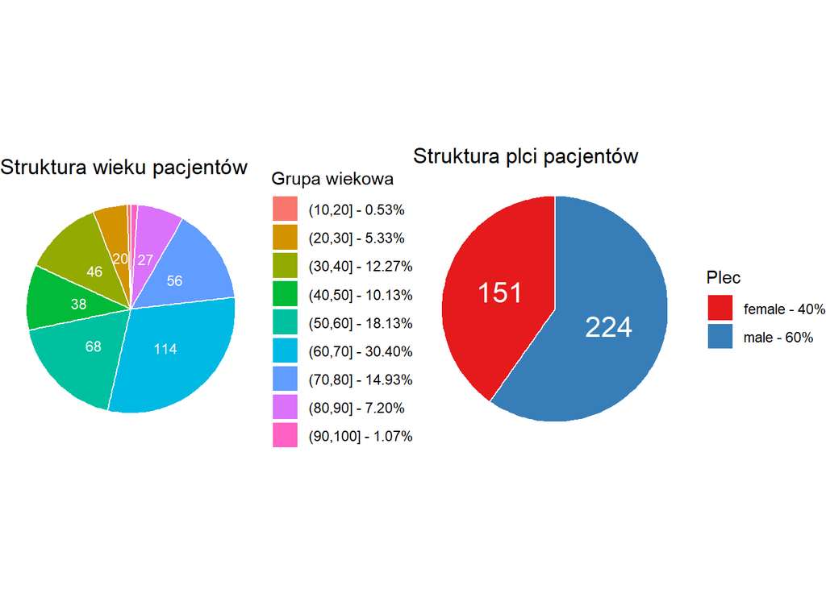

### Hospitalizacja

Minimalnym czasem hospitalizacji był 0:02:01:57 (dd:hh:mm:ss), a maksymalnym - 35:04:05:54. Średnim czasem jaki pacjenci spędzili w szpitalu był 10:20:29:08.

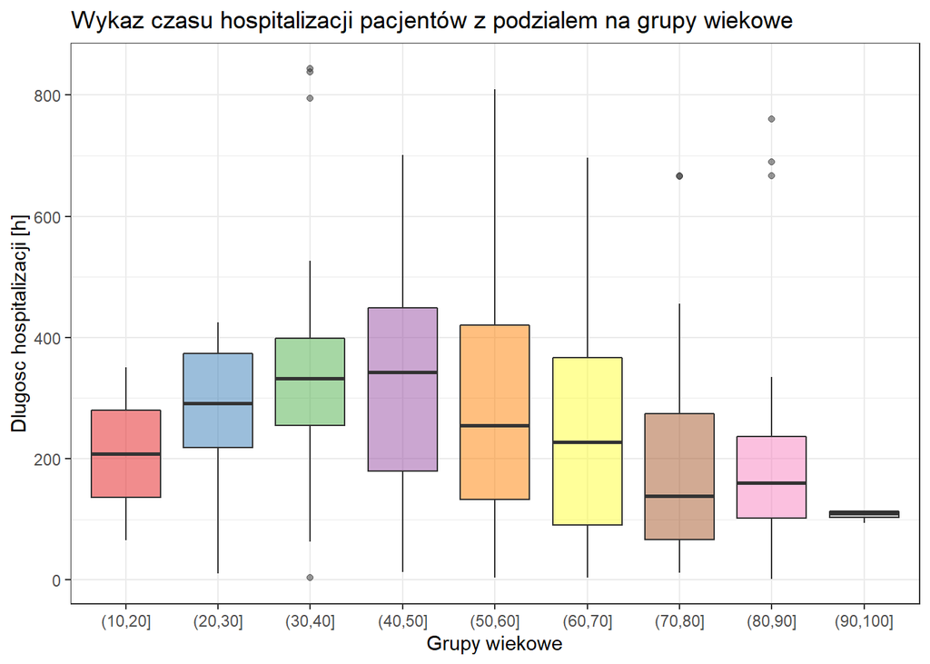

Pełna dystrybucja czasu hospitalizacja jest przedstawiona w tabeli poniżej:

| age_group | Mean | Max | Min | Standard_deviation |
| --- | --- | --- | --- | --- |
| (10,20] | 8:16:05:49 | 14:15:13:49 | 2:16:57:48 | 8:10:25:16 |
| (20,30] | 11:13:04:00 | 17:16:22:40 | 0:10:44:51 | 4:22:31:21 |
| (30,40] | 14:02:16:38 | 35:04:05:54 | 0:03:50:46 | 7:02:59:42 |
| (40,50] | 13:13:26:15 | 29:04:45:21 | 0:12:57:09 | 7:12:09:37 |
| (50,60] | 11:07:50:50 | 33:17:10:13 | 0:03:40:29 | 7:16:55:57 |
| (60,70] | 10:10:54:04 | 29:00:38:10 | 0:03:55:53 | 7:13:14:12 |
| (70,80] | 7:18:15:24 | 27:18:53:29 | 0:11:46:57 | 6:14:10:13 |
| (80,90] | 9:00:41:43 | 31:16:54:28 | 0:02:01:57 | 8:04:20:22 |
| (90,100] | 4:10:55:24 | 4:18:31:13 | 3:21:22:44 | 0:09:38:49 |

### Śmiertelność

Bezwględna śmiertelność pacjentów ze zbioru danych wyniosła 46.4%.

Tabela z procentowo wyrażoną śmiertelnością w zależności od grupy wiekowej

| survived | (10,20] | (20,30] | (30,40] | (40,50] | (50,60] | (60,70] | (70,80] | (80,90] | (90,100] | Combined |
| --- | --- | --- | --- | --- | --- | --- | --- | --- | --- | --- |
| yes | 50.00% | 100.00% | 97.83% | 81.58% | 63.24% | 43.86% | 12.50% | 14.81% | 0.00% | 53.60% |
| no | 50.00% | 0.00% | 2.17% | 18.42% | 36.76% | 56.14% | 87.50% | 85.19% | 100.00% | 46.40% |

Najbardziej narażeni byli pacjenci z grupy wiekowej (90,100], których śmiertelność wyniosła 100.0%, ale jest to również jedna z najmniej licznych grup pacjentów.

Najmniej narażoną grupą byli pacjenci w wieku (20,30], u których nie zanotowano przypadków śmiertelnych.

Dodatkowo ze względu na małą reprezentację grupy wiekowej (10,20], tylko dwóch pacjentów - przypadek śmiertelny oraz ozdrowiciel, współczynnik śmiertelności (oraz przeżywalności) jest przekłamany.

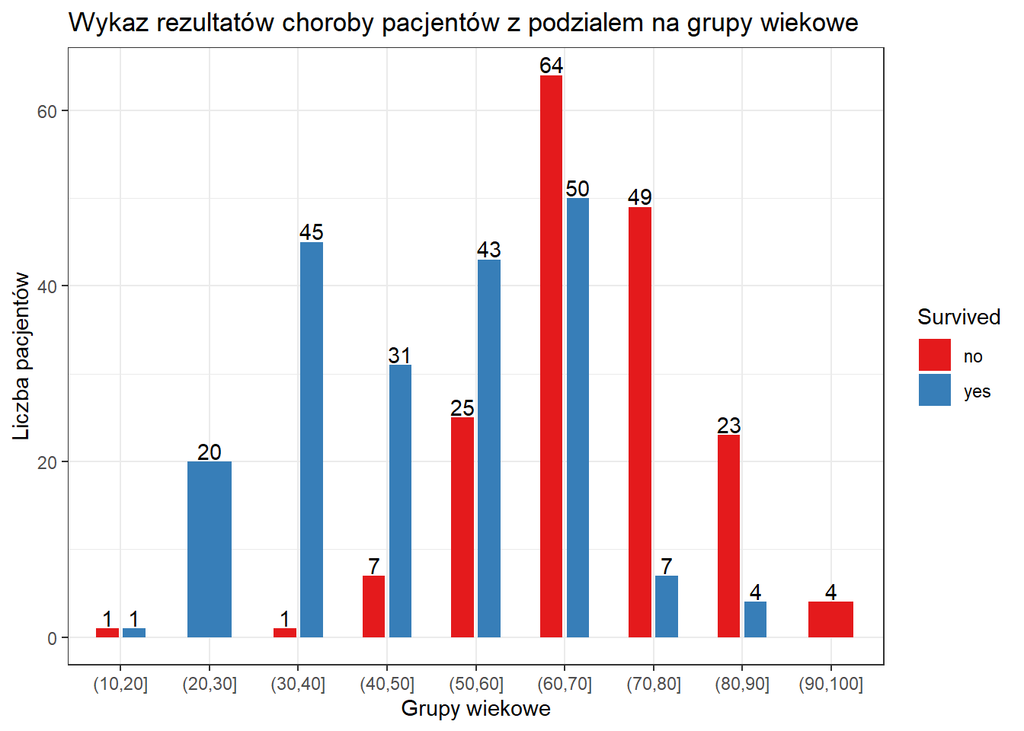

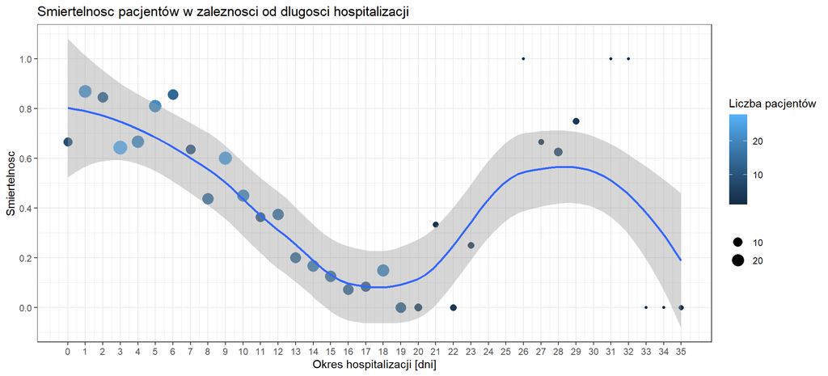